# Task 3

### Unusual observations

There are peak demands in the summer months and in the beginning of the year. This can be seen in every year.

### Conclusions

The demand for electricity ranges between 6.2 and 7.6 GWh per month. One can observe two peaks per year, one in the summer and one in the beginning of every year while the peak during summer appears to be bigger than the one in the winter. A possible explanation are the high need for heating with electricity during the summer since Australia is in the southern hemisphere and has therefore a cold summer. Overall, there is no upward/downward trend over the observed years. To confirm the findings, the data will be aggregated by month over the year (mean).

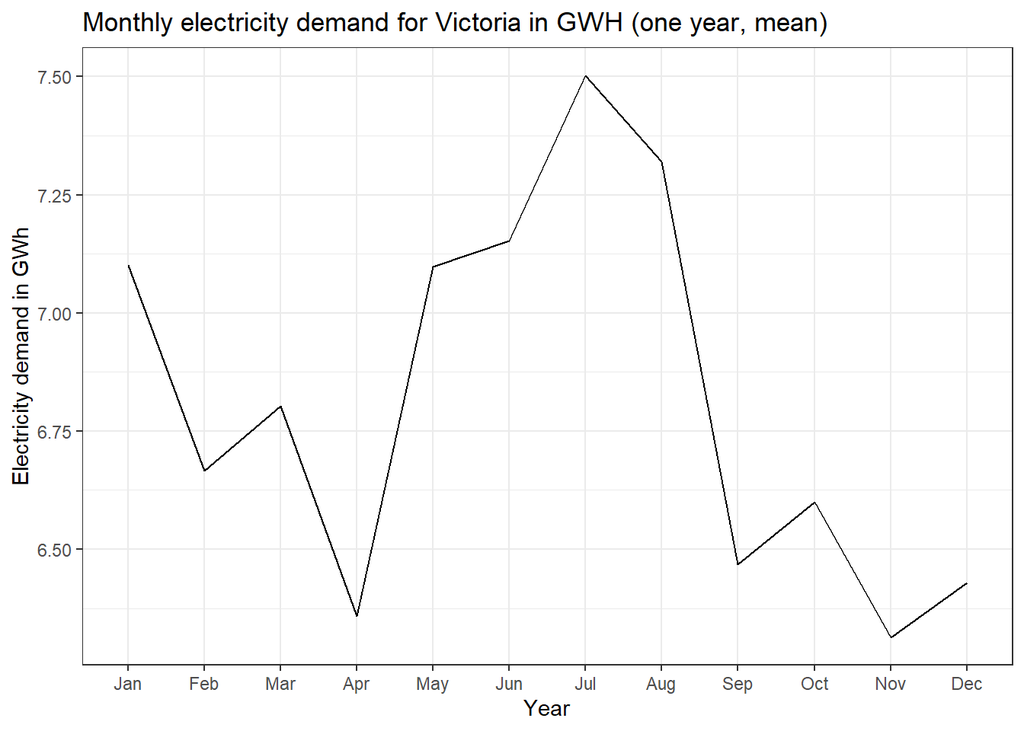

```r
agg_demand_avg = aggregate(agg_demand$Demand, list(agg_demand$Month), mean) # aggregate the data from before by month by taking the mean of every month
agg_demand_avg = rename(agg_demand_avg, # rename columns
  "Month" = Group.1,
  "Demand" = x
)
agg_demand_avg$Month.Abb = month.abb[agg_demand_avg$Month] # create a new column to store the abbreviations of the months
ggplot(agg_demand_avg, aes(x = reorder(Month.Abb, Month), y = Demand/1000000, group = 1)) + # create a new ggplot with Date on the x-axis and demand in GWh on the y-axis
  geom_line() + # make it a line-plot
  labs(title = "Monthly electricity demand for Victoria in GWH (one year, mean)", x = "Year", y = "Electricity demand in GWh") + # set the labels
  theme_bw() #+ # change the theme
```

```r
  #scale_x_discrete(limits = month.abb)
```

This graph confirms the findings from above. There is a peak in the summer and a smaller peak in the beginning of the year.

## References

### Packages

Hyndman R (2023). *fpp3: Data for “Forecasting: Principles and Practice” (3rd Edition)*. R package version 0.5, https://CRAN.R-project.org/package=fpp3.

H. Wickham. ggplot2: Elegant Graphics for Data Analysis. Springer-Verlag New York, 2016.

Garrett Grolemund, Hadley Wickham (2011). Dates and Times Made Easy with lubridate. Journal of Statistical Software, 40(3), 1-25. URL https://www.jstatsoft.org/v40/i03/.